# **Description:**

- This code file was created for a kaggle competition: **https://www.kaggle.com/competitions/opencv-pytorch-project-1-classification**
- The best score achived using this file is **81.16%**

### **About the competition:**

- This project is a multi-class classification project, where you have to classify each image into any one of the 3 animal classes: Cat, Dog and Panda.
- The evaluation metric chosen is Accuracy Score

## 3.1. Import Libraries

```python
import os
import time
from dataclasses import dataclass
from typing import List, Union, Tuple

import numpy as np
import pandas as pd
from tqdm import tqdm
import matplotlib.pyplot as plt

import torch.nn as nn
import torch.optim as optim
import torch.nn.functional as F
from torch.optim import lr_scheduler
from torch.utils.tensorboard import SummaryWriter

from torchvision import datasets, transforms

from torchmetrics import MeanMetric
from torchmetrics.classification import MulticlassAccuracy



# Text formatting
bold = "\033[1m"
end = "\033[0m"

plt.style.use('ggplot')
block_plot=False

%matplotlib inline
```

### explore data

```python
root_dir = r"/kaggle/input/opencv-pytorch-project-1-classification/dataset"

train_dir = os.path.join(root_dir, "Train")
valid_dir = os.path.join(root_dir, "Valid")
```

```python
 from torchvision import datasets
```

```python
train_dir = os.path.join(root_dir, "Train")
valid_dir = os.path.join(root_dir, "Valid")
```

```python
train_data = datasets.ImageFolder(train_dir)
validation_data = datasets.ImageFolder(valid_dir)
```

### 3.2.1. Compulsary Preprocessing Transforms

```python
def image_preprocess_transforms(img_size):
    preprocess = transforms.Compose(
        [
            transforms.Resize(224),
            transforms.CenterCrop(img_size),
            transforms.ToTensor(),
        ]
    )

    return preprocess
```

### 3.2.2. Common Image Transforms

```python
def image_common_transforms(img_size=(224, 224), mean=(0.4611, 0.4359, 0.3905), std=(0.2193, 0.2150, 0.2109)):
    preprocess = image_preprocess_transforms(img_size)

    common_transforms = transforms.Compose(
        [
            preprocess,
            transforms.Normalize(mean, std),
        ]
    )

    return common_transforms
```

### 3.2.3. Mean and STD

Function for Calculating Mean and Variance.

```python
def get_mean_std(data_root, img_size=(224, 224), num_workers=4):
    transform = image_preprocess_transforms(img_size=img_size)

    loader = data_loader(data_root, transform)

    batch_mean = torch.zeros(3)
    batch_mean_sqrd = torch.zeros(3)

    for batch_data, _ in loader:
        batch_mean += batch_data.mean(dim=(0, 2, 3))  # E[batch_i]
        batch_mean_sqrd += (batch_data**2).mean(dim=(0, 2, 3))  #  E[batch_i**2]

    # E[dataset] = E[E[batch_1], E[batch_2], ...]
    mean = batch_mean / len(loader)

    # var[X] = E[X**2] - E[X]**2

    # E[X**2] = E[E[batch_1**2], E[batch_2**2], ...]
    # E[X]**2 = E[E[batch_1], E[batch_2], ...] ** 2

    var = (batch_mean_sqrd / len(loader)) - (mean**2)

    std = var**0.5
    print("mean: {}, std: {}".format(mean, std))

    return mean, std
```

## 3.3. Data Loaders

### 3.3.1. Data Loader for Full Data

Data loader for generating batches of data to be used by the training routine

```python
def data_loader(data_root, transform, batch_size=16, shuffle=False, num_workers=2):
    dataset = datasets.ImageFolder(root=data_root, transform=transform)

    loader = torch.utils.data.DataLoader(
        dataset,
        batch_size=batch_size,
        num_workers=num_workers,
        shuffle=shuffle,
    )

    return loader
```

### subset of data

```python
import torch

subset_size = 0.05
```

```python
def data_subset_loader(data_root, transform, batch_size=16, shuffle=False, num_workers=2):

    dataset = datasets.ImageFolder(root=data_root, transform=transform)

    subset = torch.utils.data.Subset(dataset, np.arange(0, len(dataset), 1.0 / subset_size).astype(int))

    loader = torch.utils.data.DataLoader(
        subset,
        batch_size=batch_size,
        num_workers=num_workers,
        shuffle=shuffle,
    )

    return loader
```

```python
img_size = (224, 224)
num_workers = 2

mean, std = get_mean_std(data_root=train_dir, img_size=img_size, num_workers=num_workers)
common_transforms = image_common_transforms(img_size, mean, std)

train_subset_loader = data_subset_loader(train_dir, common_transforms, batch_size=16, shuffle=True, num_workers=2)
validation_subset_loader = data_subset_loader(valid_dir, common_transforms, batch_size=16, shuffle=True, num_workers=2)
```

```
mean: tensor([0.4603, 0.4356, 0.3900]), std: tensor([0.2715, 0.2626, 0.2614])
```

## 3.4. Prepare Data

The main function which uses all the above functions to generate the train and valid dataloaders.

```python
def data_augmentation_preprocess(img_size=(224, 224), mean=(0.4611, 0.4359, 0.3905), std=(0.2193, 0.2150, 0.2109)):
    preprocess = image_preprocess_transforms(img_size)

    augmentation_transforms = transforms.Compose(
        [
            preprocess,
            transforms.RandomHorizontalFlip(),
            transforms.RandomAffine(degrees=(-0.1, 0.1), translate=(0.1, 0.1), scale=(0.95, 1.05)),
            transforms.Normalize(mean, std),
        ]
    )

    return augmentation_transforms
```

```python
def get_data(batch_size, data_root, img_size=(224, 224), num_workers=4, data_augmentation=False):
#     YOUR CODE HERE

    train_data_path = os.path.join(data_root, "Train")

    mean, std = get_mean_std(data_root=train_data_path, img_size=img_size, num_workers=num_workers)

    common_transforms = image_preprocess_transforms(img_size)  # image_common_transforms(img_size, mean, std)

    # If data_augmentation is true data augmentation will be applied.
    if data_augmentation:
        train_transforms = data_augmentation_preprocess(img_size, mean, std)
    # Else simply do common transforms
    else:
        train_transforms = common_transforms

    # Train dataloader
    train_loader = data_loader(                    # data_subset_loader   # data_loader
        train_data_path,
        train_transforms,
        batch_size=batch_size,
        shuffle=True,
        num_workers=num_workers,
    )

    # Valid dataloader
    valid_data_path = os.path.join(data_root, "Valid")

    valid_loader = data_loader(            # data_subset_loader
        valid_data_path,
        train_transforms,
        batch_size=batch_size,
        shuffle=False,
        num_workers=num_workers,
    )

    return train_loader, valid_loader
```

# Step 4: Train Your Model

Now, create the training pipeline, and train your model on the full data.

### 4.1.1. System Configuration

Fix the seed (e.g., `21`) to get a reproducible result.

```python
@dataclass
class SystemConfig:
    """
    Describes the common system setting needed for reproducible training
    """

    seed: int = 21  # Seed number to set the state of all random number generators
    cudnn_benchmark_enabled: bool = True  # Enable CuDNN benchmark for the sake of performance
    cudnn_deterministic: bool = True  # Make cudnn deterministic (reproducible training)
```

### 4.1.2. Training Configuration

```python
@dataclass
class TrainingConfig:
    """
    Describes configuration of the training process
    """

    num_classes: int = 3
    batch_size: int = 32
    img_size: Tuple = (224, 224)
    epochs_count: int = 40
    init_learning_rate: float = 0.001  # Initial learning rate
    data_root: str = "/kaggle/input/opencv-pytorch-project-1-classification/dataset"
    num_workers: int = 2
    device: str = "cuda"  # "cuda" # "cpu"

    # For tensorboard logging and saving checkpoints
    save_model_name: str = "cat_dog_panda_classifier.pt"
    root_log_dir: str = os.path.join("Logs_Checkpoints", "Model_logs")
    root_checkpoint_dir: str = os.path.join("Logs_Checkpoints", "Model_checkpoints")

    # Current log and checkpoint directory.
    log_dir: str = "version_0"
    checkpoint_dir: str = "version_0"
```

### 4.1.3. System Setup

```python
def setup_system(system_config: SystemConfig) -> None:
    torch.manual_seed(system_config.seed)
    if torch.cuda.is_available():
        torch.backends.cudnn_benchmark_enabled = system_config.cudnn_benchmark_enabled
        torch.backends.cudnn.deterministic = system_config.cudnn_deterministic
```

## 4.2. Training Function

In the next code cell, we are going to define the training function, which is a crucial step in our deep learning pipeline. This function will handle the processes involved in training, including feeding data to the model, adjusting weights, and optimizing performance.

You are already familiar with the training function. No changes needed here.

```python
def train(
    train_config: TrainingConfig,
    model: nn.Module,
    optimizer: torch.optim.Optimizer,
    train_loader: torch.utils.data.DataLoader,
    epoch_idx: int,
    total_epochs: int,
) -> Tuple[float, float]:

    # Change model in training mode.
    model.train()

    acc_metric = MulticlassAccuracy(num_classes=train_config.num_classes, average="micro")
    mean_metric = MeanMetric()

    device = train_config.device

    status = f"Train:\t{bold}Epoch: {epoch_idx}/{total_epochs}{end}"

    prog_bar = tqdm(train_loader, bar_format="{l_bar}{bar:10}{r_bar}{bar:-10b}")

    prog_bar.set_description(status)

    for data, target in prog_bar:
        # Send data and target to appropriate device.
        data, target = data.to(device), target.to(device)

        # Reset parameters gradient to zero.
        optimizer.zero_grad()

        # Forward pass to the model.
        output = model(data)

        # Cross Entropy loss
        loss = F.cross_entropy(output, target)

        # Find gradients w.r.t training parameters.
        loss.backward()

        # Update parameters using gradients.
        optimizer.step()

        # Batch Loss.
        mean_metric(loss.item(), weight=data.shape[0])

        # # Get probability score using softmax.
        # prob = F.softmax(output, dim=1)

        # Get the index of the max probability.
        pred_idx = output.detach().argmax(dim=1)

        # Batch accuracy.
        acc_metric(pred_idx.cpu(), target.cpu())

        # Update progress bar description.
        step_status = status + f" Train Loss: {mean_metric.compute():.4f}, Train Acc: {acc_metric.compute():.4f}"
        prog_bar.set_description(step_status)

    epoch_loss = mean_metric.compute()
    epoch_acc = acc_metric.compute()

    prog_bar.close()

    return epoch_loss, epoch_acc
```

## 4.3. Validation Function

In the upcoming code cell, we will create the validation function. This function is essential for assessing the performance of our model on unseen data, ensuring its effectiveness and accuracy.

```python
def validate(
    train_config: TrainingConfig,
    model: nn.Module,
    valid_loader: torch.utils.data.DataLoader,
    epoch_idx: int,
    total_epochs: int
) -> Tuple[float, float]:

    # Change model in evaluation mode.
    model.eval()

    acc_metric = MulticlassAccuracy(num_classes=train_config.num_classes, average="micro")
    mean_metric = MeanMetric()

    device = train_config.device

    status = f"Valid:\t{bold}Epoch: {epoch_idx}/{total_epochs}{end}"

    prog_bar = tqdm(valid_loader, bar_format="{l_bar}{bar:10}{r_bar}{bar:-10b}")

    prog_bar.set_description(status)

    for data, target in prog_bar:
        # Send data and target to appropriate device.
        data, target = data.to(device), target.to(device)

        # Get the model's predicted logits.
        with torch.no_grad():
            output = model(data)

        # Compute the CE-Loss.
        valid_loss = F.cross_entropy(output, target).item()

        # Batch validation loss.
        mean_metric(valid_loss, weight=data.shape[0])

        # # Convert model's logits to probability scores.
        # prob = F.softmax(output, dim=1)

        # Get the index of the max probability.
        pred_idx = output.detach().argmax(dim=1)

        # Batch accuracy.
        acc_metric(pred_idx.cpu(), target.cpu())

        # Update progress bar description.
        step_status = status + f" Valid Loss: {mean_metric.compute():.4f}, Valid Acc: {acc_metric.compute():.4f}"
        prog_bar.set_description(step_status)

    valid_loss = mean_metric.compute()
    valid_acc = acc_metric.compute()

    prog_bar.close()

    return valid_loss, valid_acc
```

## 4.4. Save & Load Model

The following two code cells are dedicated to essential functions in deep learning model management:

1. **Saving the Model Function**: This function is crucial for preserving the trained model state, allowing us to store the learned parameters for future use or further analysis.
2. **Loading the Model Function**: This function is designed to retrieve and load a previously saved model. It's vital for resuming training, making predictions, or conducting evaluations without having to retrain the model from scratch.

```python
def save_model(model, device, model_dir="models", model_file_name="cat_dog_panda_classifier.pt"):
    if not os.path.exists(model_dir):
        os.makedirs(model_dir)

    model_path = os.path.join(model_dir, model_file_name)

    # Make sure you transfer the model to cpu.
    if device == "cuda":
        model.to("cpu")

    # Save the 'state_dict'
    torch.save(model.state_dict(), model_path)

    if device == "cuda":
        model.to("cuda")

    return
```

```python
def load_model(model, model_dir="models", model_file_name="cat_dog_panda_classifier.pt", device=torch.device("cpu")):
    model_path = os.path.join(model_dir, model_file_name)

    # Load model parameters by using 'load_state_dict'.
    model.load_state_dict(torch.load(model_path, map_location=device))

    return model
```

## 4.5. Logging Setup

This function will be initializing directories so that they save tensorboard and model checkpoints for different training versions.

```python
def setup_log_directory(training_config=TrainingConfig()):
    """Tensorboard Log and Model checkpoint directory Setup"""

    if os.path.isdir(training_config.root_log_dir):
        # Get all folders numbers in the root_log_dir.
        folder_numbers = [int(folder.replace("version_", "")) for folder in os.listdir(training_config.root_log_dir)]

        # Find the latest version number present in the log_dir
        last_version_number = max(folder_numbers)

        # New version name
        version_name = f"version_{last_version_number + 1}"

    else:
        version_name = training_config.log_dir

    # Update the training config default directory.
    training_config.log_dir = os.path.join(training_config.root_log_dir, version_name)
    training_config.checkpoint_dir = os.path.join(training_config.root_checkpoint_dir, version_name)

    # Create new directory for saving new experiment version.
    os.makedirs(training_config.log_dir, exist_ok=True)
    os.makedirs(training_config.checkpoint_dir, exist_ok=True)

    print(f"Logging at: {training_config.log_dir}")
    print(f"Model Checkpoint at: {training_config.checkpoint_dir}")

    return training_config, version_name
```

## 4.6. Plot Loss and Accuracy

The next code cell will focus on developing a function for plotting loss and accuracy graphs. This function is instrumental in visualizing the performance of the deep learning model throughout the training process, providing insights into its learning behavior by displaying trends in loss reduction and accuracy improvement over epochs.

```python
def plot_loss_accuracy(
    train_loss,
    val_loss,
    train_acc,
    val_acc,
    colors,
    loss_legend_loc="upper center",
    acc_legend_loc="upper left",
    fig_size=(20, 10),
    sub_plot1=(1, 2, 1),
    sub_plot2=(1, 2, 2),
):
    plt.rcParams["figure.figsize"] = fig_size
    fig = plt.figure()
    plt.subplot(sub_plot1[0], sub_plot1[1], sub_plot1[2])

    for i in range(len(train_loss)):
        x_train = range(len(train_loss[i]))
        x_val = range(len(val_loss[i]))

        min_train_loss = min(train_loss[i])
        min_val_loss = min(val_loss[i])

        plt.plot(x_train, train_loss[i], linestyle="-", color=f"tab:{colors[i]}", label=f"TRAIN LOSS ({min_train_loss:.4})")
        plt.plot(x_val, val_loss[i], linestyle="--", color=f"tab:{colors[i]}", label=f"VALID LOSS ({min_val_loss:.4})")


    plt.xlabel("epoch no.")
    plt.ylabel("loss")
    plt.legend(loc=loss_legend_loc)
    plt.title("Training and Validation Loss")
    plt.subplot(sub_plot2[0], sub_plot2[1], sub_plot2[2])

    for i in range(len(train_acc)):
        x_train = range(len(train_acc[i]))
        x_val = range(len(val_acc[i]))

        max_train_acc = max(train_acc[i])
        max_val_acc = max(val_acc[i])

        plt.plot(
            x_train,
            train_acc[i],
            linestyle="-",
            color=f"tab:{colors[i]}",
            label=f"TRAIN ACC ({max_train_acc:.4})",
        )

        plt.plot(
            x_val,
            val_acc[i],
            linestyle="--",
            color=f"tab:{colors[i]}",
            label=f"VALID ACC ({max_val_acc:.4})",
        )


    plt.xlabel("epoch no.")
    plt.ylabel("accuracy")
    plt.legend(loc=acc_legend_loc)
    plt.title("Training and Validation Accuracy")
    fig.savefig("sample_loss_acc_plot.png")
    plt.show()

    return
```

## 4.7. Main Function for Training

In this function, we integrate all the various functions we've previously defined, creating a cohesive and streamlined workflow.

```python
import torch.optim.lr_scheduler as lr_scheduler

def main(model, scheduler=None, system_config=SystemConfig(), training_config=TrainingConfig(), data_augmentation=True):

    # Setup system configuration.
    setup_system(system_config)

    # Initialize data loader
    train_loader, valid_loader = get_data(
        batch_size=training_config.batch_size,
        data_root=training_config.data_root,
        img_size=training_config.img_size,
        num_workers=training_config.num_workers,
        data_augmentation=data_augmentation,
    )

    # Number of epochs to train.
    NUM_EPOCHS = training_config.epochs_count

    # Set acceleration device.
    device = torch.device("cuda") if torch.cuda.is_available() else torch.device("cpu")

    # Send model to device (GPU/CPU)
    model.to(device)

    # Initialize Adam optimizer.
    optimizer = optim.Adam(model.parameters(), lr=training_config.init_learning_rate)
    scheduler = lr_scheduler.ExponentialLR(optimizer, gamma=0.88, verbose=False)

    best_loss = torch.tensor(np.inf)

    # Epoch train & valid loss accumulator.
    epoch_train_loss = []
    epoch_valid_loss = []

    # Epoch train & valid accuracy accumulator.
    epoch_train_acc = []
    epoch_valid_acc = []

    # Trainig time measurement
    t_begin = time.time()

    for epoch in range(NUM_EPOCHS):
        train_loss, train_acc = train(training_config, model, optimizer, train_loader, epoch + 1, NUM_EPOCHS)
        val_loss, val_accuracy = validate(training_config, model, valid_loader, epoch + 1, NUM_EPOCHS)

        scheduler.step()

        epoch_train_loss.append(train_loss)
        epoch_train_acc.append(train_acc)

        epoch_valid_loss.append(val_loss)
        epoch_valid_acc.append(val_accuracy)

#         summary_writer.add_scalar("Loss/Train", train_loss, epoch)
#         summary_writer.add_scalar("Accuracy/Train", train_acc, epoch)

#         summary_writer.add_scalar("Loss/Validation", val_loss, epoch)
#         summary_writer.add_scalar("Accuracy/Validation", val_accuracy, epoch)

        if val_loss < best_loss:
            best_loss = val_loss
            print(f"\nModel Improved... Saving Model ... ", end="")
            torch.save(model.state_dict(), os.path.join(training_config.checkpoint_dir, training_config.save_model_name))
            print("Done.\n")

        print(f"{'='*72}\n")

    print(f"Total time: {(time.time() - t_begin):.2f}s, Best Loss: {best_loss:.3f}")

    return epoch_train_loss, epoch_train_acc, epoch_valid_loss, epoch_valid_acc
```

## Define Model

```python
from torchvision.ops import Conv2dNormActivation

class MyModel(nn.Module):
    def __init__(self):
        super().__init__()

        spatial_dropout_rate = 0.3

        self._model = nn.Sequential(
            Conv2dNormActivation(in_channels=3, out_channels=64, padding=0, kernel_size=3),
            nn.MaxPool2d(kernel_size=2),


            Conv2dNormActivation(in_channels=64, out_channels=128, padding=0, kernel_size=3),
            nn.MaxPool2d(kernel_size=2),

            Conv2dNormActivation(in_channels=128, out_channels=256, padding=0, kernel_size=3),
            nn.MaxPool2d(kernel_size=2),

            Conv2dNormActivation(in_channels=256, out_channels=612, padding="same", kernel_size=3),
            nn.Dropout2d(p=spatial_dropout_rate),
            Conv2dNormActivation(in_channels=612, out_channels=256, padding="same", kernel_size=3),

            Conv2dNormActivation(in_channels=256, out_channels=128, padding=0, kernel_size=3),
            nn.MaxPool2d(kernel_size=2),

            Conv2dNormActivation(in_channels=128, out_channels=64, padding=0, kernel_size=3),
            nn.MaxPool2d(kernel_size=2),
            nn.Dropout2d(p=spatial_dropout_rate),

            nn.Flatten(),

            nn.Linear(in_features=64 * 5 * 5, out_features=100),
            nn.ReLU(inplace=True),

            nn.Linear(in_features=100, out_features=50),
            nn.ReLU(inplace=True),

            nn.Linear(in_features=50, out_features=3)
        )

    def forward(self, x):
        x = self._model(x)
        return x
```

## 4.9. Training

```python
model = MyModel()
print(model)

training_config = TrainingConfig()

# Model checkpoint log dir setup.
training_config, current_version_name = setup_log_directory(training_config)

# Tensorboard log dir setup. - Doesn't work in Kaggle
# summary_writer = SummaryWriter(training_config.log_dir)
```

```
MyModel(
  (_model): Sequential(
    (0): Conv2dNormActivation(
      (0): Conv2d(3, 64, kernel_size=(3, 3), stride=(1, 1), bias=False)
      (1): BatchNorm2d(64, eps=1e-05, momentum=0.1, affine=True, track_running_stats=True)
      (2): ReLU(inplace=True)
    )
    (1): MaxPool2d(kernel_size=2, stride=2, padding=0, dilation=1, ceil_mode=False)
    (2): Conv2dNormActivation(
      (0): Conv2d(64, 128, kernel_size=(3, 3), stride=(1, 1), bias=False)
      (1): BatchNorm2d(128, eps=1e-05, momentum=0.1, affine=True, track_running_stats=True)
      (2): ReLU(inplace=True)
    )
    (3): MaxPool2d(kernel_size=2, stride=2, padding=0, dilation=1, ceil_mode=False)
    (4): Conv2dNormActivation(
      (0): Conv2d(128, 256, kernel_size=(3, 3), stride=(1, 1), bias=False)
      (1): BatchNorm2d(256, eps=1e-05, momentum=0.1, affine=True, track_running_stats=True)
      (2): ReLU(inplace=True)
    )
    (5): MaxPool2d(kernel_size=2, stride=2, padding=0, dilation=1, ceil_mode=False)
    (6): Conv2dNormActivation(
      (0): Conv2d(256, 612, kernel_size=(3, 3), stride=(1, 1), padding=same, bias=False)
      (1): BatchNorm2d(612, eps=1e-05, momentum=0.1, affine=True, track_running_stats=True)
      (2): ReLU(inplace=True)
    )
    (7): Dropout2d(p=0.3, inplace=False)
    (8): Conv2dNormActivation(
      (0): Conv2d(612, 256, kernel_size=(3, 3), stride=(1, 1), padding=same, bias=False)
      (1): BatchNorm2d(256, eps=1e-05, momentum=0.1, affine=True, track_running_stats=True)
      (2): ReLU(inplace=True)
    )
    (9): Conv2dNormActivation(
      (0): Conv2d(256, 128, kernel_size=(3, 3), stride=(1, 1), bias=False)
      (1): BatchNorm2d(128, eps=1e-05, momentum=0.1, affine=True, track_running_stats=True)
      (2): ReLU(inplace=True)
    )
    (10): MaxPool2d(kernel_size=2, stride=2, padding=0, dilation=1, ceil_mode=False)
    (11): Conv2dNormActivation(
      (0): Conv2d(128, 64, kernel_size=(3, 3), stride=(1, 1), bias=False)
      (1): BatchNorm2d(64, eps=1e-05, momentum=0.1, affine=True, track_running_stats=True)
      (2): ReLU(inplace=True)
    )
    (12): MaxPool2d(kernel_size=2, stride=2, padding=0, dilation=1, ceil_mode=False)
    (13): Dropout2d(p=0.3, inplace=False)
    (14): Flatten(start_dim=1, end_dim=-1)
    (15): Linear(in_features=1600, out_features=100, bias=True)
    (16): ReLU(inplace=True)
    (17): Linear(in_features=100, out_features=50, bias=True)
    (18): ReLU(inplace=True)
    (19): Linear(in_features=50, out_features=3, bias=True)
  )
)
Logging at: Logs_Checkpoints/Model_logs/version_0
Model Checkpoint at: Logs_Checkpoints/Model_checkpoints/version_0
```

```python
# Train and Validate
train_loss, train_acc, val_loss, val_acc = main(
    model,
#     summary_writer=summary_writer,
    scheduler=None,
    system_config=SystemConfig(),
    training_config=training_config,
    data_augmentation=True,
)
```

```
mean: tensor([0.4603, 0.4356, 0.3900]), std: tensor([0.2715, 0.2626, 0.2614])
```

```
Train:	Epoch: 1/40 Train Loss: 0.8057, Train Acc: 0.5786: 100%|██████████| 66/66 [00:13<00:00,  4.81it/s]
Valid:	Epoch: 1/40 Valid Loss: 0.7685, Valid Acc: 0.6100: 100%|██████████| 10/10 [00:02<00:00,  3.52it/s]
```

```
Model Improved... Saving Model ... Done.

========================================================================
```

```
Train:	Epoch: 2/40 Train Loss: 0.7168, Train Acc: 0.6129: 100%|██████████| 66/66 [00:12<00:00,  5.29it/s]
Valid:	Epoch: 2/40 Valid Loss: 1.0848, Valid Acc: 0.5333: 100%|██████████| 10/10 [00:01<00:00,  5.75it/s]
```

```
Train:	Epoch: 3/40 Train Loss: 0.6858, Train Acc: 0.6419: 100%|██████████| 66/66 [00:12<00:00,  5.33it/s]
Valid:	Epoch: 3/40 Valid Loss: 0.7262, Valid Acc: 0.6000: 100%|██████████| 10/10 [00:01<00:00,  5.52it/s]
```

```
Model Improved... Saving Model ... Done.

========================================================================
```

```
Train:	Epoch: 4/40 Train Loss: 0.6489, Train Acc: 0.6700: 100%|██████████| 66/66 [00:12<00:00,  5.28it/s]
Valid:	Epoch: 4/40 Valid Loss: 0.6923, Valid Acc: 0.6800: 100%|██████████| 10/10 [00:01<00:00,  5.81it/s]
```

```
Model Improved... Saving Model ... Done.

========================================================================
```

```
Train:	Epoch: 5/40 Train Loss: 0.6144, Train Acc: 0.6910: 100%|██████████| 66/66 [00:12<00:00,  5.19it/s]
Valid:	Epoch: 5/40 Valid Loss: 0.6367, Valid Acc: 0.6533: 100%|██████████| 10/10 [00:01<00:00,  5.71it/s]
```

```
Model Improved... Saving Model ... Done.

========================================================================
```

```
Train:	Epoch: 6/40 Train Loss: 0.5893, Train Acc: 0.7062: 100%|██████████| 66/66 [00:12<00:00,  5.21it/s]
Valid:	Epoch: 6/40 Valid Loss: 0.6244, Valid Acc: 0.7167: 100%|██████████| 10/10 [00:01<00:00,  5.81it/s]
```

```
Model Improved... Saving Model ... Done.

========================================================================
```

```
Train:	Epoch: 7/40 Train Loss: 0.5910, Train Acc: 0.7010: 100%|██████████| 66/66 [00:12<00:00,  5.12it/s]
Valid:	Epoch: 7/40 Valid Loss: 0.6132, Valid Acc: 0.6667: 100%|██████████| 10/10 [00:01<00:00,  5.77it/s]
```

```
Model Improved... Saving Model ... Done.

========================================================================
```

```
Train:	Epoch: 8/40 Train Loss: 0.5571, Train Acc: 0.7195: 100%|██████████| 66/66 [00:12<00:00,  5.10it/s]
Valid:	Epoch: 8/40 Valid Loss: 0.5575, Valid Acc: 0.7500: 100%|██████████| 10/10 [00:01<00:00,  5.90it/s]
```

```
Model Improved... Saving Model ... Done.

========================================================================
```

```
Train:	Epoch: 9/40 Train Loss: 0.5518, Train Acc: 0.7433: 100%|██████████| 66/66 [00:13<00:00,  5.05it/s]
Valid:	Epoch: 9/40 Valid Loss: 0.5595, Valid Acc: 0.7300: 100%|██████████| 10/10 [00:01<00:00,  5.72it/s]
```

```
Train:	Epoch: 10/40 Train Loss: 0.5159, Train Acc: 0.7390: 100%|██████████| 66/66 [00:12<00:00,  5.10it/s]
Valid:	Epoch: 10/40 Valid Loss: 0.5764, Valid Acc: 0.7300: 100%|██████████| 10/10 [00:01<00:00,  5.58it/s]
```

```
Train:	Epoch: 11/40 Train Loss: 0.5014, Train Acc: 0.7643: 100%|██████████| 66/66 [00:12<00:00,  5.10it/s]
Valid:	Epoch: 11/40 Valid Loss: 0.7966, Valid Acc: 0.7100: 100%|██████████| 10/10 [00:01<00:00,  5.71it/s]
```

```
Train:	Epoch: 12/40 Train Loss: 0.4877, Train Acc: 0.7767: 100%|██████████| 66/66 [00:12<00:00,  5.13it/s]
Valid:	Epoch: 12/40 Valid Loss: 0.4948, Valid Acc: 0.7567: 100%|██████████| 10/10 [00:01<00:00,  5.83it/s]
```

```
Model Improved... Saving Model ... Done.

========================================================================
```

```
Train:	Epoch: 13/40 Train Loss: 0.4820, Train Acc: 0.7719: 100%|██████████| 66/66 [00:12<00:00,  5.10it/s]
Valid:	Epoch: 13/40 Valid Loss: 0.5362, Valid Acc: 0.7633: 100%|██████████| 10/10 [00:01<00:00,  5.53it/s]
```

```
Train:	Epoch: 14/40 Train Loss: 0.4543, Train Acc: 0.7910: 100%|██████████| 66/66 [00:12<00:00,  5.11it/s]
Valid:	Epoch: 14/40 Valid Loss: 0.4936, Valid Acc: 0.7700: 100%|██████████| 10/10 [00:01<00:00,  5.39it/s]
```

```
Model Improved... Saving Model ... Done.

========================================================================
```

```
Train:	Epoch: 15/40 Train Loss: 0.4318, Train Acc: 0.7962: 100%|██████████| 66/66 [00:12<00:00,  5.08it/s]
Valid:	Epoch: 15/40 Valid Loss: 0.4800, Valid Acc: 0.7533: 100%|██████████| 10/10 [00:01<00:00,  5.66it/s]
```

```
Model Improved... Saving Model ... Done.

========================================================================
```

```
Train:	Epoch: 16/40 Train Loss: 0.4251, Train Acc: 0.8114: 100%|██████████| 66/66 [00:12<00:00,  5.12it/s]
Valid:	Epoch: 16/40 Valid Loss: 0.4569, Valid Acc: 0.7667: 100%|██████████| 10/10 [00:01<00:00,  5.65it/s]
```

```
Model Improved... Saving Model ... Done.

========================================================================
```

```
Train:	Epoch: 17/40 Train Loss: 0.4216, Train Acc: 0.8086: 100%|██████████| 66/66 [00:12<00:00,  5.12it/s]
Valid:	Epoch: 17/40 Valid Loss: 0.4344, Valid Acc: 0.8000: 100%|██████████| 10/10 [00:01<00:00,  5.27it/s]
```

```
Model Improved... Saving Model ... Done.

========================================================================
```

```
Train:	Epoch: 18/40 Train Loss: 0.4035, Train Acc: 0.8157: 100%|██████████| 66/66 [00:12<00:00,  5.10it/s]
Valid:	Epoch: 18/40 Valid Loss: 0.4579, Valid Acc: 0.7800: 100%|██████████| 10/10 [00:01<00:00,  5.39it/s]
```

```
Train:	Epoch: 19/40 Train Loss: 0.4130, Train Acc: 0.8114: 100%|██████████| 66/66 [00:13<00:00,  5.07it/s]
Valid:	Epoch: 19/40 Valid Loss: 0.4551, Valid Acc: 0.7933: 100%|██████████| 10/10 [00:01<00:00,  5.60it/s]
```

```
Train:	Epoch: 20/40 Train Loss: 0.3946, Train Acc: 0.8233: 100%|██████████| 66/66 [00:12<00:00,  5.08it/s]
Valid:	Epoch: 20/40 Valid Loss: 0.4255, Valid Acc: 0.7967: 100%|██████████| 10/10 [00:01<00:00,  5.72it/s]
```

```
Model Improved... Saving Model ... Done.

========================================================================
```

```
Train:	Epoch: 21/40 Train Loss: 0.3861, Train Acc: 0.8233: 100%|██████████| 66/66 [00:12<00:00,  5.11it/s]
Valid:	Epoch: 21/40 Valid Loss: 0.4177, Valid Acc: 0.7967: 100%|██████████| 10/10 [00:01<00:00,  5.89it/s]
```

```
Model Improved... Saving Model ... Done.

========================================================================
```

```
Train:	Epoch: 22/40 Train Loss: 0.3697, Train Acc: 0.8381: 100%|██████████| 66/66 [00:12<00:00,  5.09it/s]
Valid:	Epoch: 22/40 Valid Loss: 0.4047, Valid Acc: 0.8033: 100%|██████████| 10/10 [00:01<00:00,  5.71it/s]
```

```
Model Improved... Saving Model ... Done.

========================================================================
```

```
Train:	Epoch: 23/40 Train Loss: 0.3534, Train Acc: 0.8371: 100%|██████████| 66/66 [00:12<00:00,  5.09it/s]
Valid:	Epoch: 23/40 Valid Loss: 0.4477, Valid Acc: 0.8067: 100%|██████████| 10/10 [00:01<00:00,  5.80it/s]
```

```
Train:	Epoch: 24/40 Train Loss: 0.3747, Train Acc: 0.8376: 100%|██████████| 66/66 [00:12<00:00,  5.09it/s]
Valid:	Epoch: 24/40 Valid Loss: 0.3924, Valid Acc: 0.8300: 100%|██████████| 10/10 [00:01<00:00,  5.67it/s]
```

```
Model Improved... Saving Model ... Done.

========================================================================
```

```
Train:	Epoch: 25/40 Train Loss: 0.3639, Train Acc: 0.8329: 100%|██████████| 66/66 [00:12<00:00,  5.11it/s]
Valid:	Epoch: 25/40 Valid Loss: 0.3608, Valid Acc: 0.8433: 100%|██████████| 10/10 [00:01<00:00,  5.86it/s]
```

```
Model Improved... Saving Model ... Done.

========================================================================
```

```
Train:	Epoch: 26/40 Train Loss: 0.3548, Train Acc: 0.8457: 100%|██████████| 66/66 [00:12<00:00,  5.10it/s]
Valid:	Epoch: 26/40 Valid Loss: 0.3998, Valid Acc: 0.8200: 100%|██████████| 10/10 [00:01<00:00,  5.56it/s]
```

```
Train:	Epoch: 27/40 Train Loss: 0.3348, Train Acc: 0.8586: 100%|██████████| 66/66 [00:12<00:00,  5.10it/s]
Valid:	Epoch: 27/40 Valid Loss: 0.4159, Valid Acc: 0.8000: 100%|██████████| 10/10 [00:01<00:00,  5.80it/s]
```

```
Train:	Epoch: 28/40 Train Loss: 0.3397, Train Acc: 0.8500: 100%|██████████| 66/66 [00:12<00:00,  5.09it/s]
Valid:	Epoch: 28/40 Valid Loss: 0.3847, Valid Acc: 0.8200: 100%|██████████| 10/10 [00:01<00:00,  5.88it/s]
```

```
Train:	Epoch: 29/40 Train Loss: 0.3282, Train Acc: 0.8619: 100%|██████████| 66/66 [00:12<00:00,  5.11it/s]
Valid:	Epoch: 29/40 Valid Loss: 0.4139, Valid Acc: 0.8300: 100%|██████████| 10/10 [00:01<00:00,  5.82it/s]
```

```
Train:	Epoch: 30/40 Train Loss: 0.3361, Train Acc: 0.8529: 100%|██████████| 66/66 [00:12<00:00,  5.09it/s]
Valid:	Epoch: 30/40 Valid Loss: 0.3930, Valid Acc: 0.8267: 100%|██████████| 10/10 [00:02<00:00,  4.94it/s]
```

```
Train:	Epoch: 31/40 Train Loss: 0.3303, Train Acc: 0.8538: 100%|██████████| 66/66 [00:12<00:00,  5.10it/s]
Valid:	Epoch: 31/40 Valid Loss: 0.3844, Valid Acc: 0.8400: 100%|██████████| 10/10 [00:01<00:00,  5.44it/s]
```

```
Train:	Epoch: 32/40 Train Loss: 0.3242, Train Acc: 0.8571: 100%|██████████| 66/66 [00:12<00:00,  5.12it/s]
Valid:	Epoch: 32/40 Valid Loss: 0.3978, Valid Acc: 0.8300: 100%|██████████| 10/10 [00:01<00:00,  5.83it/s]
```

```
Train:	Epoch: 33/40 Train Loss: 0.3309, Train Acc: 0.8695: 100%|██████████| 66/66 [00:13<00:00,  5.06it/s]
Valid:	Epoch: 33/40 Valid Loss: 0.3756, Valid Acc: 0.8300: 100%|██████████| 10/10 [00:01<00:00,  5.69it/s]
```

```
Train:	Epoch: 34/40 Train Loss: 0.3228, Train Acc: 0.8629: 100%|██████████| 66/66 [00:12<00:00,  5.12it/s]
Valid:	Epoch: 34/40 Valid Loss: 0.4108, Valid Acc: 0.8233: 100%|██████████| 10/10 [00:01<00:00,  5.46it/s]
```

```
Train:	Epoch: 35/40 Train Loss: 0.3191, Train Acc: 0.8643: 100%|██████████| 66/66 [00:13<00:00,  5.07it/s]
Valid:	Epoch: 35/40 Valid Loss: 0.3963, Valid Acc: 0.8300: 100%|██████████| 10/10 [00:01<00:00,  5.21it/s]
```

```
Train:	Epoch: 36/40 Train Loss: 0.3337, Train Acc: 0.8567: 100%|██████████| 66/66 [00:12<00:00,  5.10it/s]
Valid:	Epoch: 36/40 Valid Loss: 0.3974, Valid Acc: 0.8233: 100%|██████████| 10/10 [00:01<00:00,  5.80it/s]
```

```
Train:	Epoch: 37/40 Train Loss: 0.3076, Train Acc: 0.8729: 100%|██████████| 66/66 [00:13<00:00,  5.07it/s]
Valid:	Epoch: 37/40 Valid Loss: 0.3967, Valid Acc: 0.8300: 100%|██████████| 10/10 [00:01<00:00,  5.68it/s]
```

```
Train:	Epoch: 38/40 Train Loss: 0.3123, Train Acc: 0.8724: 100%|██████████| 66/66 [00:12<00:00,  5.10it/s]
Valid:	Epoch: 38/40 Valid Loss: 0.4106, Valid Acc: 0.8167: 100%|██████████| 10/10 [00:01<00:00,  5.78it/s]
```

```
Train:	Epoch: 39/40 Train Loss: 0.3092, Train Acc: 0.8619: 100%|██████████| 66/66 [00:12<00:00,  5.08it/s]
Valid:	Epoch: 39/40 Valid Loss: 0.4048, Valid Acc: 0.8167: 100%|██████████| 10/10 [00:01<00:00,  5.56it/s]
```

```
Train:	Epoch: 40/40 Train Loss: 0.3254, Train Acc: 0.8590: 100%|██████████| 66/66 [00:12<00:00,  5.13it/s]
Valid:	Epoch: 40/40 Valid Loss: 0.4120, Valid Acc: 0.8300: 100%|██████████| 10/10 [00:01<00:00,  5.73it/s]
```

```
========================================================================

Total time: 589.81s, Best Loss: 0.361
```

## 4.10. Loss and Accuracy Plot

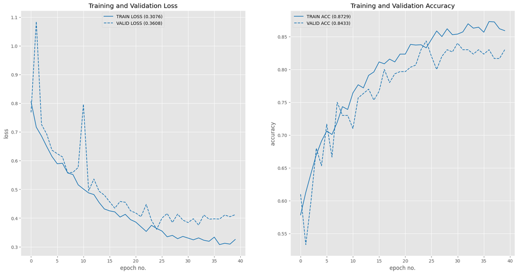

```python
plot_loss_accuracy(
    train_loss=[train_loss],
    val_loss=[val_loss],
    train_acc=[train_acc],
    val_acc=[val_acc],
    colors=["blue"],
    loss_legend_loc="upper center",
    acc_legend_loc="upper left",
)
```

# Step 5. Sample Prediction

Show some sample predictions.

## 5.1. Make Predictions

```python
def prediction(model, device, batch_input):
    data = batch_input.to(device)

    with torch.no_grad():
        output = model(data)

    # Score to probability using softmax.
    prob = F.softmax(output, dim=1)

    # Get the max probability.
    pred_prob = prob.data.max(dim=1)[0]

    # Get the index of the max probability.
    pred_index = prob.data.max(dim=1)[1]

    return pred_index.cpu().numpy(), pred_prob.cpu().numpy()
```

## 5.2. Get Predictions on a Batch

```python
def get_sample_prediction(model, data_root, img_size, mean, std):
    batch_size = 300

    if torch.cuda.is_available():
        device = "cuda"
        num_workers = 8
    else:
        device = "cpu"
        num_workers = 2

    # It is important to do model.eval() before prediction.
    model.eval()

    # Send model to cpu/cuda according to your system configuration.
    model.to(device)

    # Transformed data
    valid_dataset_trans = datasets.ImageFolder(root=data_root, transform=image_common_transforms(img_size, mean, std))

    # Original image dataset
    valid_dataset = datasets.ImageFolder(root=data_root, transform=image_preprocess_transforms(img_size))

    data_len = valid_dataset.__len__()

    interval = int(data_len / batch_size)

    imgs = []
    inputs = []
    targets = []
    for i in range(batch_size):
        index = i * interval
        trans_input, target = valid_dataset_trans.__getitem__(index)
        img, _ = valid_dataset.__getitem__(index)

        imgs.append(img)
        inputs.append(trans_input)
        targets.append(target)

    inputs = torch.stack(inputs)

    cls, prob = prediction(model, device, batch_input=inputs)

    plt.style.use("default")
    plt.rcParams["figure.figsize"] = (15, 9)
    fig = plt.figure()

    for i, target in enumerate(targets):
        if i == 15:
            break
        plt.subplot(3, 5, i + 1)
        img = transforms.functional.to_pil_image(imgs[i])
        plt.imshow(img)
        plt.gca().set_title(f"P:{valid_dataset.classes[cls[i]]}({prob[i]:.2}), T:{valid_dataset.classes[targets[i]]}")
    plt.show()

    return targets, cls
```

## 5.3. Load Model and Run Inference

Next, we will reload the best saved model and use the `get_sample_prediction` function to make some sample predictions. This step is instrumental in visually assessing the performance of our model on the validation dataset, providing a quick and practical insight into how well our model generalizes to new, unseen data.

```
mean: tensor([0.4603, 0.4356, 0.3900]), std: tensor([0.2715, 0.2626, 0.2614])
```

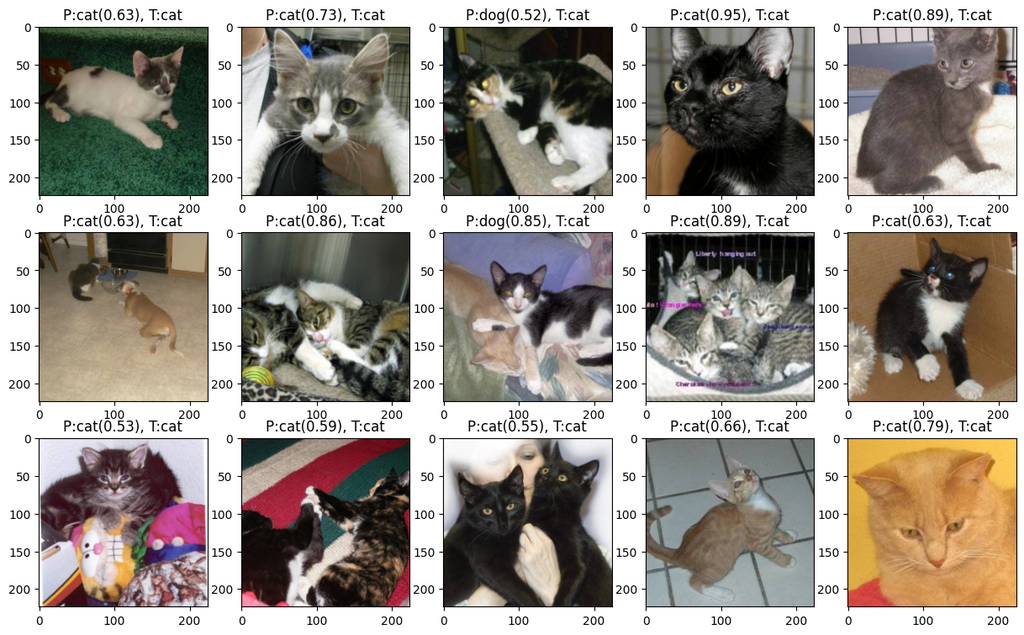

```python
trained_model = MyModel()
trained_model = load_model(
    trained_model,
    model_dir=training_config.checkpoint_dir,
    model_file_name=training_config.save_model_name
)

train_data_path = os.path.join(training_config.data_root, "Train")
valid_data_path = os.path.join(training_config.data_root, "Valid")

mean, std = get_mean_std(train_data_path, img_size=training_config.img_size)

true_labels, pred_labels = get_sample_prediction(trained_model, valid_data_path, img_size=training_config.img_size, mean=mean, std=std)
```

## Display Confusion Matrix

```
Accuracy: 84%
```

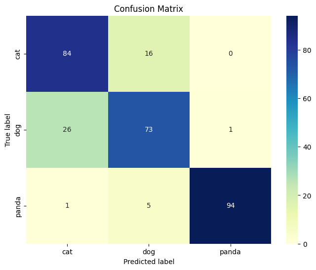

```python
# YOUR CODE HERE

import seaborn as sns
from sklearn.metrics import confusion_matrix

# Calculate confusion matrix
cm = confusion_matrix(true_labels, pred_labels)
data = pd.DataFrame(cm, index = train_data.classes, columns = train_data.classes)

# Calculate accuracy
accuracy = np.trace(cm) / np.sum(cm)

accuracy = int(round(accuracy,2) * 100)
print(f'Accuracy: {accuracy}%')

# Draw graph
plt.figure(figsize=(8, 6))
plt.title("Confusion Matrix")
sns.heatmap(data=data, annot=True, fmt='d', cmap='YlGnBu');  # 'YlGnBu'  Dark2
plt.xlabel("Predicted label")
plt.ylabel("True label")
plt.show()
```

# Step 7. Generate Submission File

**TASK**

1. Generate predictions on the test set.
2. Create a submission `.csv` file.
3. Upload the `.csv` file on Kaggle.

**REFERENCE**

1. **`test.csv`** - This CSV file contains image IDs for the test set. Read this CSV file to generate predictions for each test image.
2. **`sample_submission.csv`** - Refer to this file to understand the structure of the csv file to be submitted. The sample_submission file is only to be used as reference.  
   It contains columns:
   1. **`ID`**: same as the test.csv file
   2. **`CLASS`**: which contains random predictions

**Use the same column names that are given in the`sample_submission.csv` file.**

### Check if the sequence of filenames in the Test folder is same as IDs in the test.csv file

```python
# Get list of filenames from the Test folder
test_data_path = valid_data_path = os.path.join(training_config.data_root, "Test")
filenames = os.listdir(test_data_path)

# Get list of files from test.csv
csv_path = r"/kaggle/input/opencv-pytorch-project-1-classification/test.csv"
ID_data = pd.read_csv(csv_path)['ID']
```

```python
list_as_series = pd.Series(filenames)

# Compare the list converted to a Series with the original Series
comparison_result = ID_data.equals(list_as_series)

# Print the result of the comparison
print("Are the IDs in the Folder and the test.csv file in the same order ? : ", "Yes" if comparison_result else "No")
```

```
Are the IDs in the Folder and the test.csv file in the same order ? :  No
```

```python
label_dic = dict(zip(list(train_data.class_to_idx.values()),list(train_data.class_to_idx.keys())))
label_dic
```

```
{0: 'cat', 1: 'dog', 2: 'panda'}
```

### Common function to make predictions

```python
def denormalize(tensors, *, mean, std):
    """Denormalizes image tensors using mean and std provided
    and clip values between 0 and 1"""

    num_channels = 3
    for c in range(num_channels):
        tensors[:, c, :, :].mul_(std[c]).add_(mean[c])

    return torch.clamp(tensors, min=0.0, max=1.0)
```

```python
from PIL import Image
import random

# Function to make predictions on test data
def predict(model, test_data, device):

    predictions = []
    prob_list = []

    model.eval()  # Set the model to evaluation mode

    with torch.no_grad():  # Disable gradient calculation
        for image in test_data:

            image = image.to(device)  # Move image to device (e.g., GPU)

            output = model(image.unsqueeze(0))  # Forward pass (unsqueeze to add batch dimension)

            # _, pred = torch.max(output, 1)  # Get the predicted class index

            # Get the predicted label
            pred = torch.argmax(output, dim=1)

            # Get the probability for predicted label
            prob = F.softmax(output, dim=1)
            pred_prob = prob.data.max(dim=1)[0]

            predictions.append(label_dic[pred.item()])  # Append prediction to the list
            prob_list.append(pred_prob.item())

    return predictions, prob_list

# Randomly select images and display the predicted class
def display_predictions(test_data, pred_labels, prob_list, label_dic, IDs):

    fig = plt.figure(figsize = (15,9))

    # Select 15 random index numbers to display images
    lower_range = 0
    upper_range = len(test_data) - 1
    num_imgs = 16
    rnd_indices = random.sample(range(lower_range, upper_range), num_imgs)

    for i, idx in enumerate(rnd_indices):
        plt.subplot(4, 4, i + 1)
        img = np.transpose(test_data[idx], (1, 2, 0))
        plt.imshow(img)
        plt.gca().set_title(f"P:{pred_labels[idx]}({prob_list[idx]:.2}) {IDs[idx]}")
        plt.axis('off')
    plt.show()


def prepare_data(img_size, mean, std, test_folder_path):

    # Define transformations
    transform = image_common_transforms(img_size, mean, std)

    # Load test images
    test_data = []
    IDs = []

    for filename in os.listdir(test_folder_path):
        image = Image.open(os.path.join(test_folder_path, filename))
        try:
          image = transform(image)
        except Exception as e:
          image = image.convert('RGB')
          image = transform(image)
        finally:
          test_data.append(image)
          IDs.append(filename)

    return test_data, IDs


def predict_test(model, training_config):

    # Get test data
    test_folder_path = os.path.join(training_config.data_root, "Test")
    test_data, IDs = prepare_data(img_size, mean, std, test_folder_path)

    # Make predictions on test data
    predicted_labels, prob_list = predict(model, test_data, device = training_config.device)


    # *********************** Randomly select images and display the predicted class ***********************

    # Convert the list of images to Tensor
    test_data_tensor = (torch.stack(test_data))
    # Denormalize the data
    images = denormalize(test_data_tensor, mean=mean, std=std).squeeze().numpy()

    return IDs, predicted_labels, prob_list, images
```

### Make Predictions on Test Data and create the output.csv file

```python
import pandas as pd


### YOUR CODE HERE

# *********************** Make predictions on test data ***********************

IDs, pred_labels, prob_list, images = predict_test(trained_model, training_config)
print("Done.")


# *********************** Save to disk ***********************

test_path = r"/kaggle/working/test_opencv_proj_output.csv"

# Create a dataframe to hold the predicted labels along with the IDs i.e. the filename of the image
df_test = pd.DataFrame({"ID":IDs, "Class":pred_labels})

# Reorder the data as per the order of the IDs in the test.csv file
reordered_df = df_test.set_index('ID').loc[ID_data].reset_index()

# Save the data to the disk
reordered_df.to_csv(test_path, index=False)

###
```

```
Done.
```

### Analyze the model

[figure not shown]

```python
# Display 15 random images with predicted labels
display_predictions(images, pred_labels, prob_list, label_dic, IDs)
```

## Step 8. Kaggle Submission Score

```
Points Scored: 81.16%
```